# Introduction to Open Data Science: Rstudio Exercise 4

# Classification of the Boston Dataset

## Introduction

The data of this classification and clustering exercise was the Housing Values in Suburbs of Boston dataset, henceforth referred to just as Boston. It is available from the R package MASS, [which includes Functions and datasets to support Venables and Ripley, “Modern Applied Statistics with S” (4th edition, 2002).](https://cran.r-project.org/web/packages/MASS/index.html). According to the [reference manual of the package](https://cran.r-project.org/web/packages/MASS/MASS.pdf), the dataset includes 506 observations of the following 14 variables:

- crim: per capita crime rate by town.
- zn: proportion of residential land zoned for lots over 25,000 sq.ft.
- indus: proportion of non-retail business acres per town.
- chas: Charles River dummy variable (= 1 if tract bounds river; 0 otherwise).
- nox nitrogen oxides concentration (parts per 10 million).
- rm: average number of rooms per dwelling.
- age: proportion of owner-occupied units built prior to 1940.
- dis: weighted mean of distances to five Boston employment centres.
- rad: index of accessibility to radial highways.
- tax: full-value property-tax rate per $10,000.
- ptratio: pupil-teacher ratio by town.
- black: 1000 × (Bk − 0.63)<sup>2</sup> where Bk is the proportion of blacks by town.
- lstat: lower status of the population (percent).
- medv: median value of owner-occupied homes in $1,000s.

According to the reference manual, the data is based on the following sources:

- Harrison, D. and Rubinfeld, D.L. (1978) Hedonic prices and the demand for clean air. *J. Environ. Economics and Management* 5, 81–102.
- Belsley D.A., Kuh, E. and Welsch, R.E. (1980) *Regression Diagnostics. Identifying Influential Data and Sources of Collinearity*. New York: Wiley.

## Overview of the Data

After the MASS package has been loaded – by calling `library(MASS)` – the built-in datasets can be prepared simply by calling their names using `data()`. This enables accessing them by their names. They’re, however, loaded by using so-called lazy loading and thus only become data frames when they’re accessed for the first time (see [`help("data")`](https://stat.ethz.ch/R-manual/R-devel/library/utils/html/data.html) for details):

```r
# Prepare the data. (Quotes are optional but recommended; see help("data").)
data("Boston")
```

Glimpse the data to confirm it matches the reference manual:

```r
# The data is only turned into an actual data frame at this point.
glimpse(Boston)
```

```
## Observations: 506
## Variables: 14
## $ crim    <dbl> 0.00632, 0.02731, 0.02729, 0.03237, 0.06905, 0.02...
## $ zn      <dbl> 18.0, 0.0, 0.0, 0.0, 0.0, 0.0, 12.5, 12.5, 12.5, ...
## $ indus   <dbl> 2.31, 7.07, 7.07, 2.18, 2.18, 2.18, 7.87, 7.87, 7...
## $ chas    <int> 0, 0, 0, 0, 0, 0, 0, 0, 0, 0, 0, 0, 0, 0, 0, 0, 0...
## $ nox     <dbl> 0.538, 0.469, 0.469, 0.458, 0.458, 0.458, 0.524, ...
## $ rm      <dbl> 6.575, 6.421, 7.185, 6.998, 7.147, 6.430, 6.012, ...
## $ age     <dbl> 65.2, 78.9, 61.1, 45.8, 54.2, 58.7, 66.6, 96.1, 1...
## $ dis     <dbl> 4.0900, 4.9671, 4.9671, 6.0622, 6.0622, 6.0622, 5...
## $ rad     <int> 1, 2, 2, 3, 3, 3, 5, 5, 5, 5, 5, 5, 5, 4, 4, 4, 4...
## $ tax     <dbl> 296, 242, 242, 222, 222, 222, 311, 311, 311, 311,...
## $ ptratio <dbl> 15.3, 17.8, 17.8, 18.7, 18.7, 18.7, 15.2, 15.2, 1...
## $ black   <dbl> 396.90, 396.90, 392.83, 394.63, 396.90, 394.12, 3...
## $ lstat   <dbl> 4.98, 9.14, 4.03, 2.94, 5.33, 5.21, 12.43, 19.15,...
## $ medv    <dbl> 24.0, 21.6, 34.7, 33.4, 36.2, 28.7, 22.9, 27.1, 1...
```

Explore the data graphically:

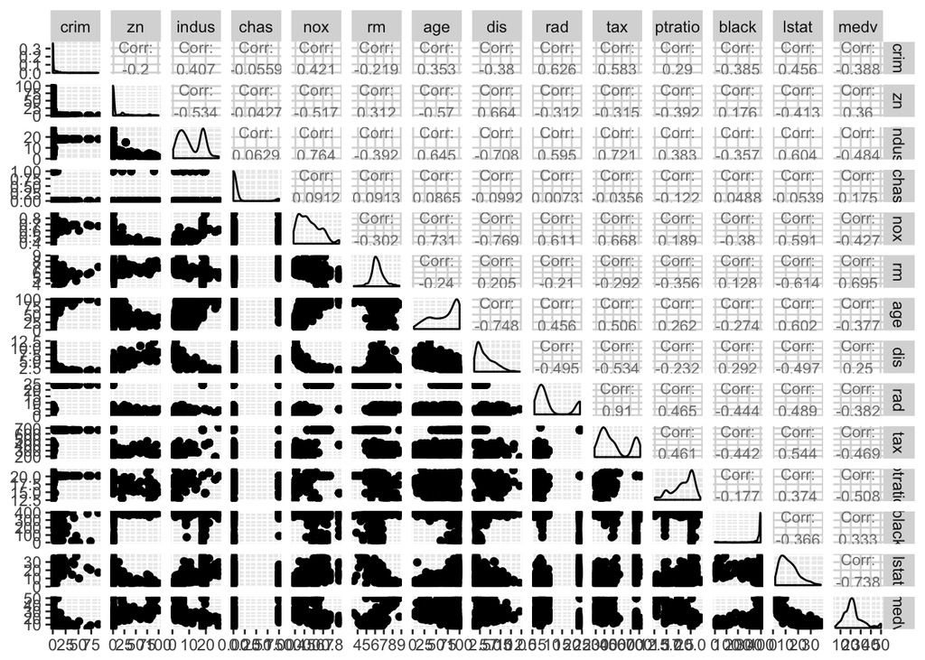

```r
# Subplot axis labels are partially too cramped, but I failed to find a working solution for that.
p <- ggpairs(Boston, mapping = aes(), lower = list(combo = wrap("facethist", bins = 10)), upper = list(continuous = wrap("cor", size=3)))
p
```

Show variable summaries:

```r
summary(Boston)
```

```
##       crim                zn             indus
##  Min.   : 0.00632   Min.   :  0.00   Min.   : 0.46
##  1st Qu.: 0.08204   1st Qu.:  0.00   1st Qu.: 5.19
##  Median : 0.25651   Median :  0.00   Median : 9.69
##  Mean   : 3.61352   Mean   : 11.36   Mean   :11.14
##  3rd Qu.: 3.67708   3rd Qu.: 12.50   3rd Qu.:18.10
##  Max.   :88.97620   Max.   :100.00   Max.   :27.74
##       chas              nox               rm             age
##  Min.   :0.00000   Min.   :0.3850   Min.   :3.561   Min.   :  2.90
##  1st Qu.:0.00000   1st Qu.:0.4490   1st Qu.:5.886   1st Qu.: 45.02
##  Median :0.00000   Median :0.5380   Median :6.208   Median : 77.50
##  Mean   :0.06917   Mean   :0.5547   Mean   :6.285   Mean   : 68.57
##  3rd Qu.:0.00000   3rd Qu.:0.6240   3rd Qu.:6.623   3rd Qu.: 94.08
##  Max.   :1.00000   Max.   :0.8710   Max.   :8.780   Max.   :100.00
##       dis              rad              tax           ptratio
##  Min.   : 1.130   Min.   : 1.000   Min.   :187.0   Min.   :12.60
##  1st Qu.: 2.100   1st Qu.: 4.000   1st Qu.:279.0   1st Qu.:17.40
##  Median : 3.207   Median : 5.000   Median :330.0   Median :19.05
##  Mean   : 3.795   Mean   : 9.549   Mean   :408.2   Mean   :18.46
##  3rd Qu.: 5.188   3rd Qu.:24.000   3rd Qu.:666.0   3rd Qu.:20.20
##  Max.   :12.127   Max.   :24.000   Max.   :711.0   Max.   :22.00
##      black            lstat            medv
##  Min.   :  0.32   Min.   : 1.73   Min.   : 5.00
##  1st Qu.:375.38   1st Qu.: 6.95   1st Qu.:17.02
##  Median :391.44   Median :11.36   Median :21.20
##  Mean   :356.67   Mean   :12.65   Mean   :22.53
##  3rd Qu.:396.23   3rd Qu.:16.95   3rd Qu.:25.00
##  Max.   :396.90   Max.   :37.97   Max.   :50.00
```

As can be seen from the output, almost all of the variables variables are continuous, with the exception of the Charles River bound tract (chas) variable, which is binary, and the radial highways accessibility variable (rad), which is an index, but still measured on an interval level.

The distribution of most variables is rather skewed, except for the dwelling size (number of rooms; rm), which is normally distributed and median value of owner-occupied homes, which is nearly normally distributed. Some variables are very highly skewed, like the crime rate (crim), proportion of land zoned for very large lots (zn) and proportion of black people (black).

There are a lot of variables in the data, so it might be helpful to calculate a correlation matrix of the data and visualise it:

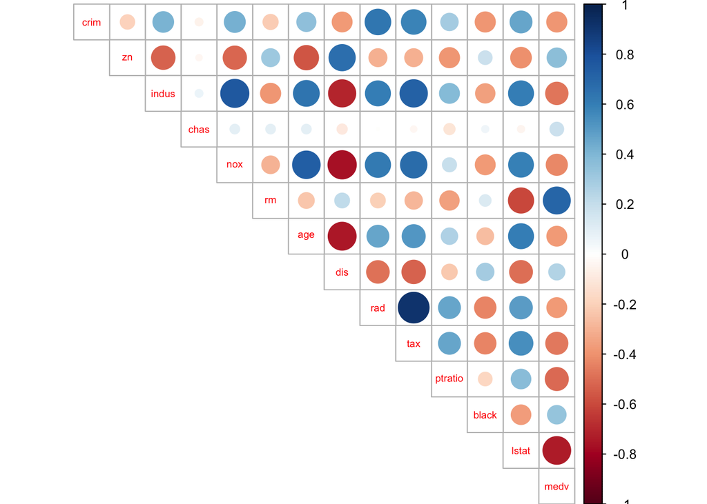

```r
# calculate the correlation matrix and round it
cor_matrix<-cor(Boston) %>% round(digits = 2)
# visualize the correlation matrix
corrplot(cor_matrix, method="circle", type="upper", tl.pos="d", tl.cex=0.6)
```

A numerical equivalent of a correlation plot including only the highest correlations might be created as follows. I personally found this to be the most intuitive way to find the highest correlations:

```r
cb <- as.data.frame(cor(Boston)) # Create a DF of the correlation matrix.
cor_matrix_high <- as.data.frame(matrix(nrow = 14, ncol = 14)) #Copy
colnames(cor_matrix_high) <- colnames(cor_matrix) #the structure of
rownames(cor_matrix_high) <- rownames(cor_matrix) #cor_matrix.
cor_threshold <- 0.7
# Loop through the correlation matrix and save only values that exceed the threshold.
for(col in names(cb)) {
  for(row in 1:length(cb[[col]])) {
    if(abs(cb[[col,row]]) > cor_threshold & abs(cb[[col,row]]) < 1) {
      cor_matrix_high[col,as.character(rownames(cb)[row])] <- round(cb[[col,row]], digits = 2)
    }
  }
}
# Print the matrix.
cor_matrix_high
```

```
##         crim zn indus chas   nox rm   age   dis  rad  tax ptratio
## crim      NA NA    NA   NA    NA NA    NA    NA   NA   NA      NA
## zn        NA NA    NA   NA    NA NA    NA    NA   NA   NA      NA
## indus     NA NA    NA   NA  0.76 NA    NA -0.71   NA 0.72      NA
## chas      NA NA    NA   NA    NA NA    NA    NA   NA   NA      NA
## nox       NA NA  0.76   NA    NA NA  0.73 -0.77   NA   NA      NA
## rm        NA NA    NA   NA    NA NA    NA    NA   NA   NA      NA
## age       NA NA    NA   NA  0.73 NA    NA -0.75   NA   NA      NA
## dis       NA NA -0.71   NA -0.77 NA -0.75    NA   NA   NA      NA
## rad       NA NA    NA   NA    NA NA    NA    NA   NA 0.91      NA
## tax       NA NA  0.72   NA    NA NA    NA    NA 0.91   NA      NA
## ptratio   NA NA    NA   NA    NA NA    NA    NA   NA   NA      NA
## black     NA NA    NA   NA    NA NA    NA    NA   NA   NA      NA
## lstat     NA NA    NA   NA    NA NA    NA    NA   NA   NA      NA
## medv      NA NA    NA   NA    NA NA    NA    NA   NA   NA      NA
##         black lstat  medv
## crim       NA    NA    NA
## zn         NA    NA    NA
## indus      NA    NA    NA
## chas       NA    NA    NA
## nox        NA    NA    NA
## rm         NA    NA    NA
## age        NA    NA    NA
## dis        NA    NA    NA
## rad        NA    NA    NA
## tax        NA    NA    NA
## ptratio    NA    NA    NA
## black      NA    NA    NA
## lstat      NA    NA -0.74
## medv       NA -0.74    NA
```

## Standardising and Categorising the Data

To further analyse the dataset, the dataset must be standardised, i.e. all variables fit to normal distribution so that the mean of every variable is zero. This can be done as follows:

```r
boston_scaled <- as.data.frame(scale(Boston))
summary(boston_scaled)
```

```
##       crim                 zn               indus
##  Min.   :-0.419367   Min.   :-0.48724   Min.   :-1.5563
##  1st Qu.:-0.410563   1st Qu.:-0.48724   1st Qu.:-0.8668
##  Median :-0.390280   Median :-0.48724   Median :-0.2109
##  Mean   : 0.000000   Mean   : 0.00000   Mean   : 0.0000
##  3rd Qu.: 0.007389   3rd Qu.: 0.04872   3rd Qu.: 1.0150
##  Max.   : 9.924110   Max.   : 3.80047   Max.   : 2.4202
##       chas              nox                rm
##  Min.   :-0.2723   Min.   :-1.4644   Min.   :-3.8764
##  1st Qu.:-0.2723   1st Qu.:-0.9121   1st Qu.:-0.5681
##  Median :-0.2723   Median :-0.1441   Median :-0.1084
##  Mean   : 0.0000   Mean   : 0.0000   Mean   : 0.0000
##  3rd Qu.:-0.2723   3rd Qu.: 0.5981   3rd Qu.: 0.4823
##  Max.   : 3.6648   Max.   : 2.7296   Max.   : 3.5515
##       age               dis               rad
##  Min.   :-2.3331   Min.   :-1.2658   Min.   :-0.9819
##  1st Qu.:-0.8366   1st Qu.:-0.8049   1st Qu.:-0.6373
##  Median : 0.3171   Median :-0.2790   Median :-0.5225
##  Mean   : 0.0000   Mean   : 0.0000   Mean   : 0.0000
##  3rd Qu.: 0.9059   3rd Qu.: 0.6617   3rd Qu.: 1.6596
##  Max.   : 1.1164   Max.   : 3.9566   Max.   : 1.6596
##       tax             ptratio            black
##  Min.   :-1.3127   Min.   :-2.7047   Min.   :-3.9033
##  1st Qu.:-0.7668   1st Qu.:-0.4876   1st Qu.: 0.2049
##  Median :-0.4642   Median : 0.2746   Median : 0.3808
##  Mean   : 0.0000   Mean   : 0.0000   Mean   : 0.0000
##  3rd Qu.: 1.5294   3rd Qu.: 0.8058   3rd Qu.: 0.4332
##  Max.   : 1.7964   Max.   : 1.6372   Max.   : 0.4406
##      lstat              medv
##  Min.   :-1.5296   Min.   :-1.9063
##  1st Qu.:-0.7986   1st Qu.:-0.5989
##  Median :-0.1811   Median :-0.1449
##  Mean   : 0.0000   Mean   : 0.0000
##  3rd Qu.: 0.6024   3rd Qu.: 0.2683
##  Max.   : 3.5453   Max.   : 2.9865
```

We can now see from the output of `summary()` that this works as intended. We also need to categorise our target variable – crim – to classify it:

```r
# Create a quantile vector of crim, and use it to create the categorical "crime".
bins <- quantile(boston_scaled$crim)
crime <- cut(boston_scaled$crim, breaks = bins, include.lowest = TRUE, label = c('low','med_low','med_high','high'))
# Replace the original unscaled variable.
boston_scaled <- dplyr::select(boston_scaled, -crim)
boston_scaled <- data.frame(boston_scaled, crime)
table(boston_scaled$crim) # Explore the categorised variable.
```

```
##
##      low  med_low med_high     high
##      127      126      126      127
```

## Dividing the Data and Fitting the Model

To create the LDA model and to test it, the data has to be divided into training and testing sets. This can be done as follows, choosing randomly 80% of the data to be used for training:

```r
n <- nrow(boston_scaled) # Get number of rows in the dataset.
ind <- sample(n,  size = n * 0.8) # Choose randomly 80% of the rows.
train <- boston_scaled[ind,] # Create train set.
test <- boston_scaled[-ind,] # Create test set.
# Save the correct classes from the test data.
correct_classes <- test$crime
# Remove the crime variable from the test data.
test <- dplyr::select(test, -crime)
```

With the data divided, it is now possible to fit the LDA model on the training set:

```r
lda.fit <- lda(crime ~ ., data = train)
lda.fit
```

```
## Call:
## lda(crime ~ ., data = train)
##
## Prior probabilities of groups:
##       low   med_low  med_high      high
## 0.2450495 0.2599010 0.2524752 0.2425743
##
## Group means:
##                  zn      indus         chas        nox          rm
## low       1.0548209 -0.9216787 -0.113254311 -0.8780516  0.43709877
## med_low  -0.1050211 -0.3109541 -0.047351911 -0.5844489 -0.11640304
## med_high -0.3947601  0.1754877  0.190859195  0.4413126  0.08620839
## high     -0.4872402  1.0171960  0.008892378  1.0618943 -0.36146445
##                 age        dis        rad        tax     ptratio
## low      -0.9081643  0.8965865 -0.6872140 -0.7439825 -0.44696497
## med_low  -0.3781138  0.3458425 -0.5432662 -0.5056341 -0.08283955
## med_high  0.4421730 -0.4036054 -0.4132674 -0.3151799 -0.27426505
## high      0.7752732 -0.8255695  1.6373367  1.5134896  0.77985517
##                black       lstat        medv
## low       0.37961586 -0.76028261  0.53997253
## med_low   0.31199864 -0.15977569  0.01217292
## med_high  0.07546639  0.05975872  0.11592924
## high     -0.79622749  0.81573336 -0.65949666
##
## Coefficients of linear discriminants:
##                 LD1          LD2         LD3
## zn       0.09103063  0.740513714 -0.95201411
## indus    0.06170376 -0.210022276  0.31525781
## chas    -0.07981763 -0.031248428  0.10569663
## nox      0.39810606 -0.588097092 -1.45403534
## rm      -0.10215239 -0.107378365 -0.11087848
## age      0.21469858 -0.348302568 -0.18537058
## dis     -0.04167746 -0.136171862  0.06275161
## rad      3.10169956  0.954983943  0.15425922
## tax      0.04770627 -0.068686489  0.37760310
## ptratio  0.13119134  0.061106792 -0.36774200
## black   -0.13310558  0.007742893  0.10950072
## lstat    0.21249169 -0.151822945  0.36272767
## medv     0.20143352 -0.287207448 -0.22258268
##
## Proportion of trace:
##    LD1    LD2    LD3
## 0.9416 0.0431 0.0153
```

As we used quantiles to categorise the original variable, we’ve four classes. Thus, the output shows that we’ve three linear discriminants, as expected. Of these, the first explains vast majority – 94% – of the between-group variance.

The first two of the model’s linear discriminants can be visualised follows. A [helper function](http://stackoverflow.com/questions/17232251/how-can-i-plot-a-biplot-for-lda-in-r) is needed to draw the arrows in the biplot:

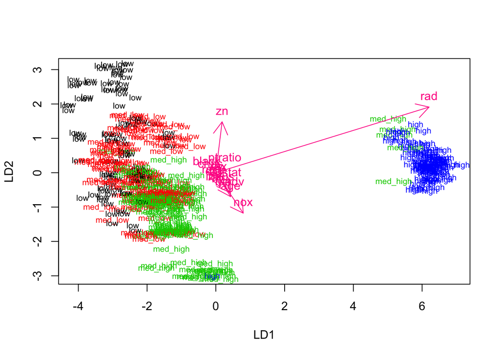

```r
# Define a function for the biplot arrows.
lda.arrows <- function(x, myscale = 2, arrow_heads = 0.2, color = "deeppink", tex = 1, choices = c(1,2)){
  heads <- coef(x)
  arrows(x0 = 0, y0 = 0,
         x1 = myscale * heads[,choices[1]],
         y1 = myscale * heads[,choices[2]], col=color, length = arrow_heads)
  text(myscale * heads[,choices], labels = row.names(heads),
       cex = tex, col=color, pos=3)
}
classes <- as.numeric(train$crime) # Turn the classes to numeric for plotting.
plot(lda.fit, dimen = 2, col = classes, pch = classes) # Plot.
lda.arrows(lda.fit) # Add arrows.
```

It’s possible to visualise all three discriminants, but the `lda.arrows()` function is incompatible with that:

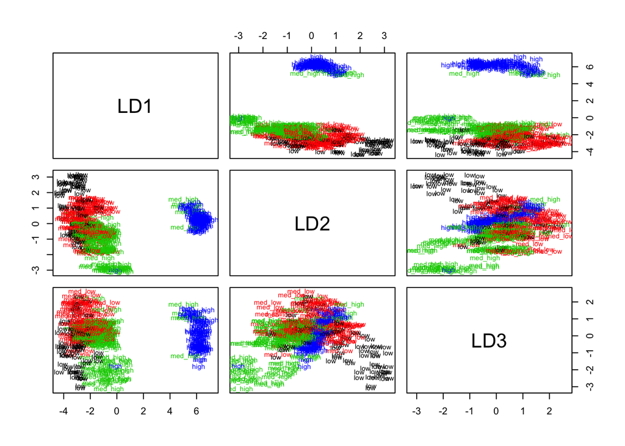

```r
plot(lda.fit, dimen = 3, col = classes, pch = classes) # Plot.
```

## Predicting with the Model

We’ve already prepared the test set above, so it’s now possible to move straight into predictions:

```r
lda.pred <- predict(lda.fit, newdata = test) # Predict the test values.
# Cross tabulate the predictions with the correct values.
addmargins(table(correct = correct_classes, predicted = lda.pred$class))
```

```
##           predicted
## correct    low med_low med_high high Sum
##   low       12      14        2    0  28
##   med_low    3      14        4    0  21
##   med_high   0       8       15    1  24
##   high       0       0        0   29  29
##   Sum       15      36       21   30 102
```

(I used ```addmargins() when tabulating, because in my opinion that’s more illustrative and helps. comparisons.) As seen from the table, the model did predict the highest of crime rates reliably, but the “med_low” category is overrepresented relative to the “low” and “med_high” categories. Thus, the model can be used to make crude predictions, but it’s hardly perfect. It might be better to use an unsupervised method and cluster the data instead of classifying it.

## Clustering the Data

To cluster the data, it needs to be loaded and standardised again, and a distance matrix created out of it:

```r
boston_scaled <- as.data.frame(scale(Boston)) # Standardise the data.
dist_eu <- dist(boston_scaled) # Create an euclidian distance matrix.
summary(dist_eu) # Summarise the matrix.
```

```
##    Min. 1st Qu.  Median    Mean 3rd Qu.    Max.
##  0.1343  3.4620  4.8240  4.9110  6.1860 14.4000
```

We can try to cluster the data with k-means straight away. We used four classes for our LDA model, so we might try it with as many clusters instead:

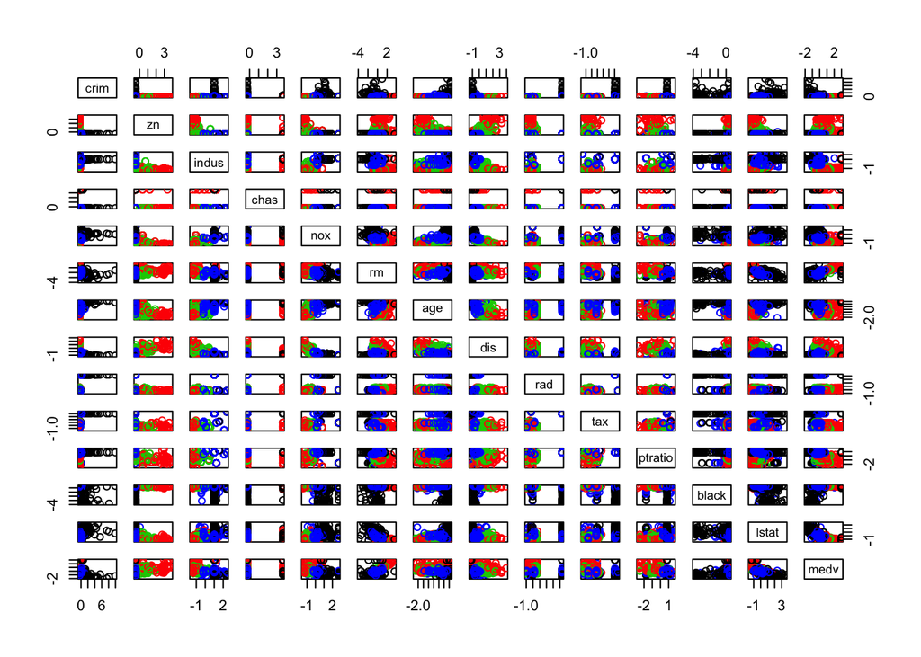

```r
km <-kmeans(dist_eu, centers = 4) # Cluster the data.
pairs(boston_scaled, col = km$cluster) # Plot the clusters.
```

However, while the results look somewhat reasonable, the amount of clusters was merely a guess. To determine it properly, the total within cluster sum of squares (TWCSS) should be calculated. Let’s try it, with a maximum of 15 clusters:

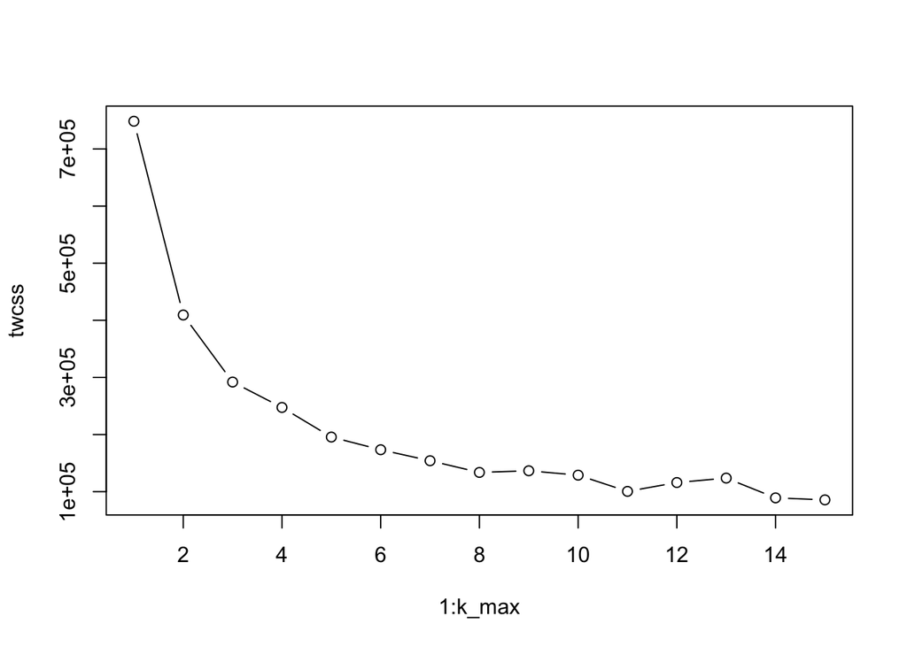

```r
k_max <- 15 # Maximum number of clusters to try.
# Define a function for testing.
k_try <- function(k) {
  kmeans(dist_eu, k)$tot.withinss
}
# Calculate the total within sum of squares using the function.
twcss <- sapply(1:k_max, k_try)

# Visualize the results.
plot(1:k_max, twcss, type='b')
```

The optimal number of cluster is where the TWCSS drops radically; however, by inspecting the above plot, it’s somewhat debatable, whether this happens with with just two or four clusters. Thus, for comparison, let’s re-cluster the data with just two clusters:

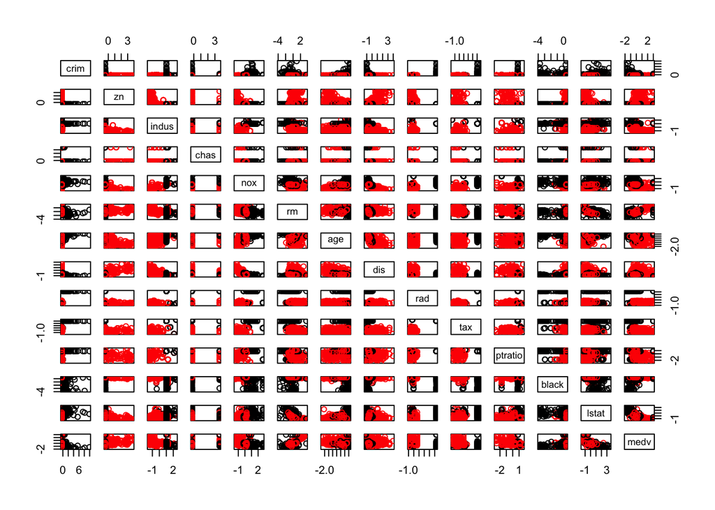

```r
km <-kmeans(dist_eu, centers = 2) # Cluster the data.
pairs(boston_scaled, col = km$cluster) # Plot the clusters.
```

As the plots above demonstrate, there seems to be less overlap between the clusters than with four clusters, which suggests that at least when using euclidian distance, the optimal number of clusters is indeed two. Because it’s possible that different distance measures produce different results, I also briefly tested my code by creating the `dist_eu` variable using the manhattan distance method instead, but found the results to be in this case so similar to the euclidian method that it’s not worth repeating those results here. The most notable difference was that with the manhattan method, the TWCSS plot hinted even more strongly that the optimal number of clusters is two.